# Claude Teamのゼミでの活用方法

作者

J22069 野倉悠正

公開

2026年10月7日

# 1 Claudeとは

[figure not shown]

[Claude](https://claude.ai)（クロード）とは、[Anthropic社](https://www.anthropic.com/)が開発した高性能な対話型生成AIおよび大規模言語モデル（LLM）[^1]である。元OpenAIの研究者らによって設立されたAnthropic社が「**安全性と信頼性に優れたAIの実現**」を掲げて開発しており、**高度な知性と人間味のある自然な対話能力**を兼ね備えている。

## 1.1 Claudeのモデル

現行[^2]のClaudeのモデルは以下の通りである。

[figure not shown]

[figure not shown]

[figure not shown]

[figure not shown]

Fableは一番性能がよく、複雑な処理に向いているが、その分使用量を消費する。逆にHaikuは性能が低いが、応答が早く使用量の消費が少ない。迷ったら**Opus**から試し、速さとコストを重視する処理は**Sonnet**、大量の軽い処理は**Haiku**、Opusでも足りない難題は**Fable**、というのが Anthropic公式の勧めに沿った選び方である。また、それぞれのモデルで思考量（Effort）を選択することができる。

**重要**

使用量はチームで共有のため、全員がFableの高エフォートを使い続けると上限にすぐ到達してしまう可能性がある。デフォルトはOpusのMediumを使用するのを遵守し、時と場合に応じたモデル・思考量設定をする必要がある。

## 1.2 Claude Code

[Claude Code](https://claude.com/ja/product/claude-code)は、ターミナルや総合開発環境（IDE）等の開発環境で直接ファイルを編集・実行する自律型コーディングAIエージェントである。AIとコードに関するやり取りを行い修正を提案してくれるだけではなく、ファイルを読み込み、実際に**AIがコードの修正、テスト、デバッグまで自動で**行ってくれる。コードをコピーする必要がなく、複数ファイルとの整合性も考慮してくれるため、開発効率を大幅に向上させることができる。基本的な利用はターミナルからになるが、GUIのデスクトップ版、VS CodeをはじめとしたIDE[^3]の拡張機能から使用することができる。

Claude Codeターミナル版の初期画面

[figure not shown]

**ヒント**

インストール方法は、3.4 Claude Codeの利用方法で解説している。

## 1.3 Claude Team

**Claude Team**は、ビジネスや教育機関向けに設計されたClaudeのサブスクリプションプランである。

**ノート特徴**

- **料金**: Standardシート[^4] ─ 月額$25/1人、Premiumシート ─ $125/1人。
- **利用人数**: 2〜150シート。
- **利用枠**: StandardシートはProプランの1.25倍、Premiumシートは6.25倍のセッションあたり使用量が提供される。
- **機能**: 全モデルへのアクセス、Claude Codeや[Cowork](https://claude.com/ja/product/cowork)[^5]の利用、プロジェクト共有機能。
- **管理・セキュリティ**: シングルサインオン（SSO）、一元的な請求管理、支出管理、職場ツール用コネクタが利用可能。

チームセッションで表示したClaudeの使用量の画面。「チーム」と表示されているのがわかる

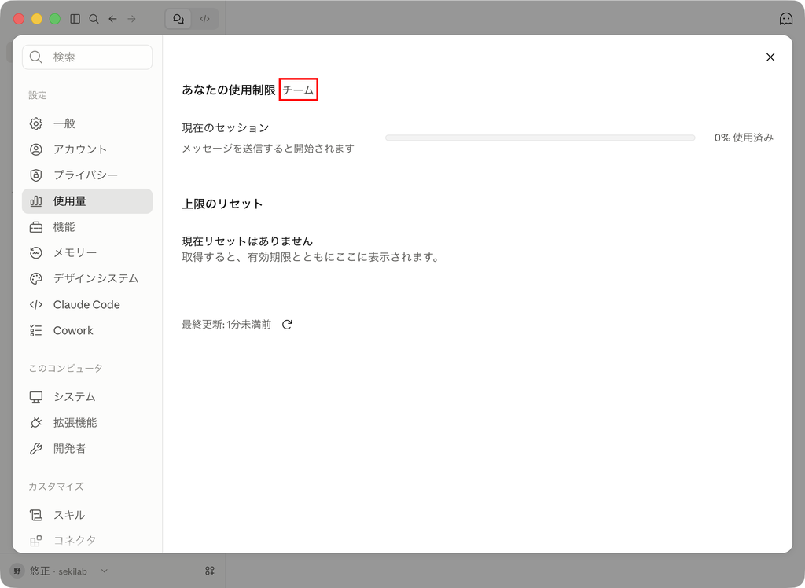

**ヒント**

なおセッションは5時間ごとに使用量がリセットされるようである。

## 1.4 Claudeと他社AIとの比較

Claudeは他のAIと比べて、高い論理性や自然な日本語表現、安全性を重視して開発されている。特にコーディングに関しては、[SWE-bench](https://www.swebench.com/)[^6]において、Claudeはトップクラスのスコア（80%以上）を記録しており、エンジニアの間で圧倒的な支持を得ている。

# 2 Claude Team導入のきっかけ

きっかけとしては、以下のXのポストを見かけ、「[**Claude Team plan for scientists**](https://claude.com/ja/programs/team-plan-for-scientists)」という研究者向けプランが無料で提供されているのを知ったことである。

> OpenAIに続き、Claudeも研究者向けにチームプランを提供とのこと！  
> （標準シートは無料、プレミアムシートも80%割引！）  
> ・自然科学、数学、コンピュータ科学、工学、および関連分野で活動する、認定された大学および非営利研究機関の主任研究者（PI）またはそれに相当する役職者が応募資格を有する… https://t.co/Ec88IlBrHh

> — [Daichi Konno / 紺野 大地](https://x.com/_daichikonno?ref_src=twsrc%5Etfw) [August 27, 2026](https://x.com/_daichikonno/status/2093093465110573207?ref_src=twsrc%5Etfw)

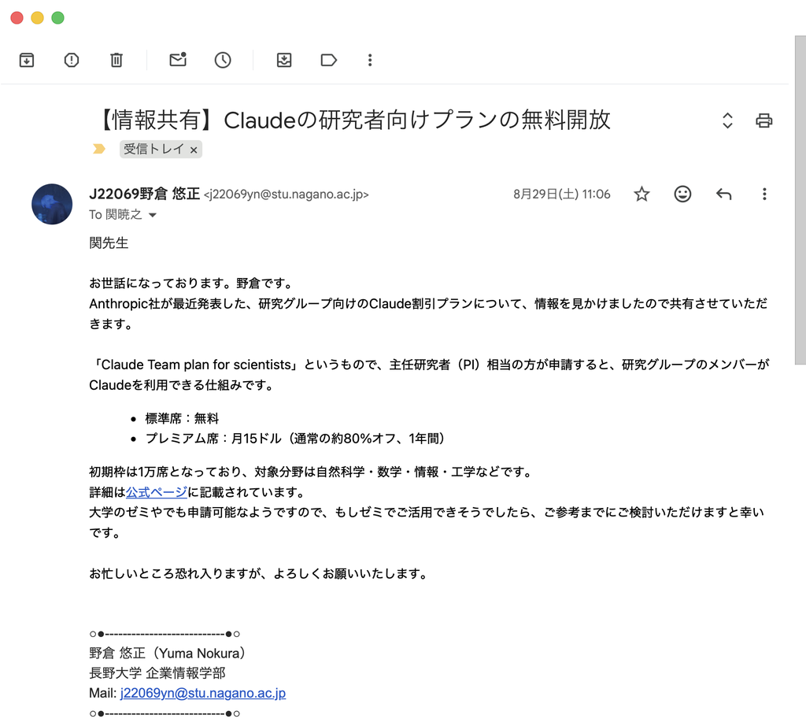

関先生に快諾していただき、早々に利用申請をしてくださったので、8月30日には利用ができるようになった。

関先生からの返信

> 野倉様

> お世話になっております。関です。 情報をお知らせいただき、誠にありがとうございました。 Anthropicより初期枠での利用が承認されました。

> まずは、野倉さんのみメンバーとして追加しています。 招待メールが野倉さんの大学のメールアドレスに届くようですので、ご確認のうえ、ご利用してみてください。

**ヒント関先生へ質問**

申請はすぐ処理され、承認されましたか？

# 3 Claude Teamの利用方法

## 3.1 Claude Teamのアカウント作成

関ゼミのチームに招待するには、管理者である関先生からの招待が必要となる。

[figure not shown]

「Accept Invite」をクリックすると、サインインページに遷移する。メールアドレスの欄に**大学のメールアドレス**を入力し、「メールで続ける」をクリックする。

**重要**

Teamプランは同じドメインのメールアドレスで登録しなければならない。必ず`@stu.nagano.ac.jp`で終わる大学のメールアドレスで登録（またはログイン）すること。

そのまま画面の指示に従い、アカウントを作成する。

## 3.2 Claudeのデスクトップアプリのインストール

インストールは、Claudeの公式サイトから可能である。

> [Claude をダウンロードする | Claude by Anthropic](https://claude.com/ja/download)

macOSの場合はDMGファイルから、Windowsの場合はMicrosoft Storeからのインストールとなる。また、モバイル版として、iOS版とAndroid版も提供されている。

**ヒント補足**

野倉は[MacbookのIntel版](https://support.apple.com/ja-jp/111932)という特殊環境であり、最新のmacOS 27ではサポートが打ち切られた情勢も相まってIntel版のテイティブアプリはリリースが廃止される傾向がある。私がよく使っているGeminiもその一つで、ネイティブアプリはApple Silicon版のみ提供であり、少々重たいブラウザ版での使用を強いられていた。しかしClaudeのアプリはIntel版でもインストールでき、かなり快適に使用できたのでそこは個人的に嬉しかった。

## 3.3 他社AIからClaudeへのメモリの移行

生成AIには、ユーザーをパーソナライズして最適な回答を生成するために「メモリ」を自動作成する。このメモリをClaudeに取り込ませることにより、Claudeを導入した初期段階から他のAIと同じ使用感で使うことが可能になる。

### 3.3.1 他社AIからメモリを抽出

**ノート**

今回はGeminiの場合だが、ChatGPTなど他のAIでも同様である。

方法としては単純で、プロンプトによりメモリを吐き出させるだけである。まずは以下のプロンプトをコピーする。

```
送信するプロンプト
```

```markdown
Export all of my stored memories and any context you've learned about me from past conversations. Preserve my words verbatim where possible, especially for instructions and preferences.

## Categories (output in this order):

1. **Instructions**: Rules I've explicitly asked you to follow going forward — tone, format, style, "always do X", "never do Y", and corrections to your behavior. Only include rules from stored memories, not from conversations.

2. **Identity**: Name, age, location, education, family, relationships, languages, and personal interests.

3. **Career**: Current and past roles, companies, and general skill areas.

4. **Projects**: Projects I meaningfully built or committed to. Ideally ONE entry per project. Include what it does, current status, and any key decisions. Use the project name or a short descriptor as the first words of the entry.

5. **Preferences**: Opinions, tastes, and working-style preferences that apply broadly.

## Format:

Use section headers for each category. Within each category, list one entry per line, sorted by oldest date first. Format each line as:

[YYYY-MM-DD] - Entry content here.

If no date is known, use [unknown] instead.

## Output:
- Wrap the entire export in a single code block for easy copying.
- After the code block, state whether this is the complete set or if more remain.
```

**ノート**

モデルが選択できる場合は、最も高性能なモデルを選択することをおすすめする。Geminiの場合である今回は、Flash 3.8の強化版思考モードで行った。

返ってきた回答を確認し、抜けがある場合は追加を要求する。今回の場合、チャットから学習した「パーソナルインテリジェンス」のメモリが欠落していたので、別途追加で要求した。

### 3.3.2 Claudeへメモリをインポートする

Claudeに戻り、「設定」＞「メモリー」を開く。「他のAIプロバイダーからメモリをインポート」という項目があるので、「インポートを開始」をクリックする。

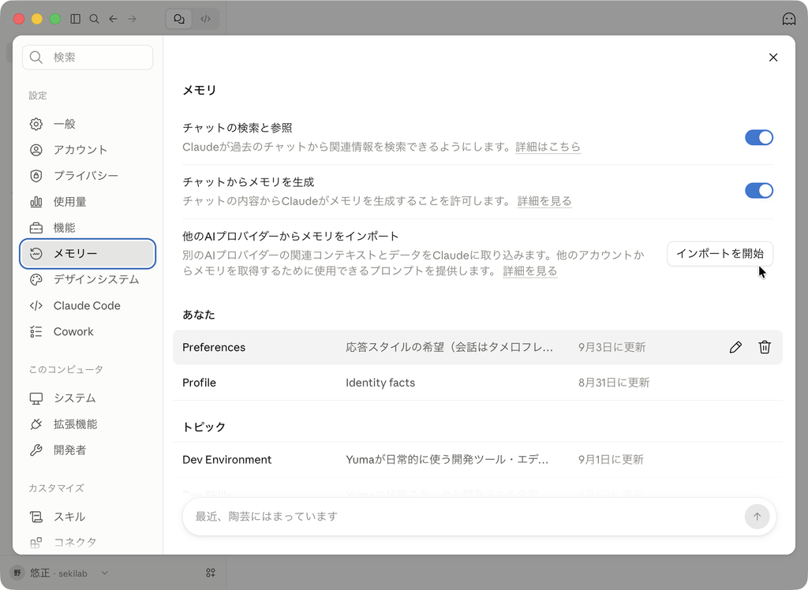

ポップアップが開くので、先程吐き出させたメモリを貼り付け、「メモリに追加」をクリック。

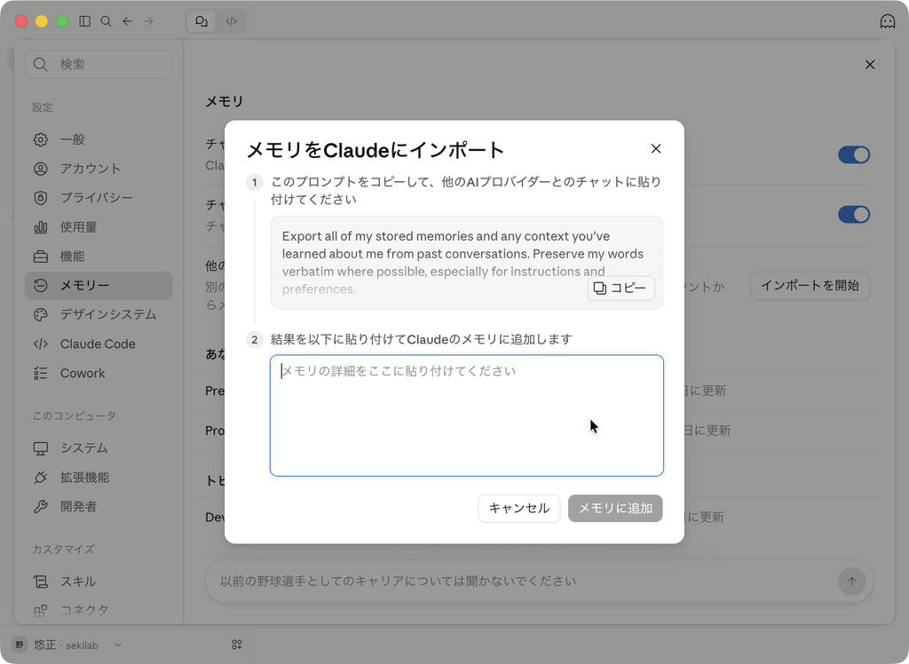

これで、今まで使っていたAIと同じような感覚でClaudeを使うことができるようになった。

## 3.4 Claude Codeの利用方法

Claude Codeデスクトップ版

[figure not shown]

### 3.4.1 ターミナル版

#### インストール

ターミナル（CLI）版は、コマンドを用いてインストールできる。

```
macOS、Linux、WSLの場合
```

```bash
curl -fsSL https://claude.ai/install.sh | bash
```

```
PowerShellの場合
```

```bash
irm https://claude.ai/install.ps1 | iex
```

インストールが完了したら、`claude --version`でコマンドが使用できるか確認する。

**ノート**

`claude`のパスが通っておらずコマンドが使えなかったので、以下のコマンドでパスを通した。

```
Zsh
```

```bash
echo 'export PATH="$HOME/.local/bin:$PATH"' >> ~/.zshrc && source ~/.zshrc
```

`claude`コマンドでClaude Codeを起動すると、以下のセットアップ画面（`Let's get started.`）になるので、まずは好きなテキストスタイルを選ぶ。

[figure not shown]

次に、Claudeのアカウントにサインインになるので、サインインに用いる方法を指定する。ここまでの方法で進めているなら、`1. Claude account with subscription`を選ぶ。

[figure not shown]

ブラウザが開くのでWeb版のClaudeと同じ手順でサインインを行う。サインインが完了すると、ターミナルに`Login successful.`と表示される。

[figure not shown]

`Enter` キーで次に進むと、推奨のセットアップを行なっていいか尋ねられる。`1. Yes, use recommended settings` を選ぶと、`Option` + `Enter` での改行や警告音の消音など、ターミナルで快適に操作するための推奨設定が自動適用される。

[figure not shown]

#### 使い方

対話モードに入るには`claude`コマンドを実行する。

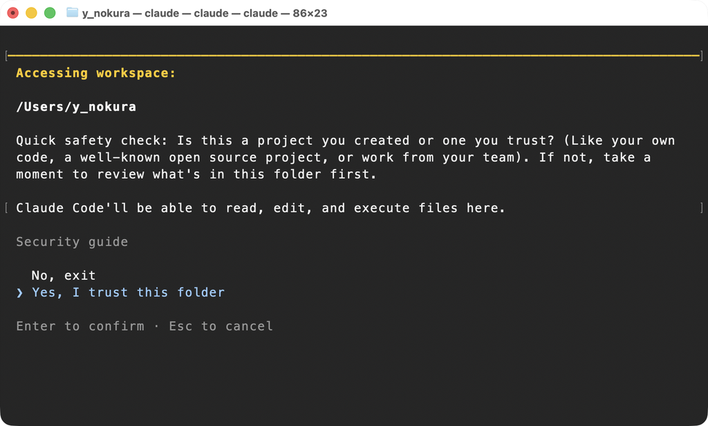

[figure not shown]

すると、左のような警告画面が出る。これはClaude Codeがターミナルのワークスペースにアクセスすることを許可するか尋ねている内容であるため、続けるには`Yes, I trust this folder`を選択し、 `Enter` を押す。すると、右のような対話モードの画面が開く。

[figure not shown]

`/model`と送信するとモデルを選択できる。上下矢印キーで**モデル**を、左右矢印キーで**思考量**を、`Enter` で**デフォルト**に設定、`S` で**このセッションのみ**の設定にすることができる。キャンセルは`Esc` キー。

[figure not shown]

また、`/effort`で思考量のみの変更も可能である。左右矢印キーで変更し、`Enter` でデフォルトに設定、`S` でこのセッションのみの設定にすることができる。キャンセルは`Esc` キー。

### 3.4.2 VS Code拡張機能

VS Codeの拡張機能としてClaude Codeのエージェントを使用することが可能である。拡張機能（`shift` + + `k`）タブの検索欄から「claude」で検索し、「**Claude Code for VS Code**」インストールする。

[figure not shown]

インストール後、左側にClaudeのアイコンが出てくるのでクリックすると、Claude Codeの拡張機能の画面になる。「＋ New Session」をクリックすると、右側のエディタ部分に対話画面が表示される。

[figure not shown]

**ノート**

基本的にターミナルのClaude Codeのセットアップができていればログインは自動でされているが、もし左上の「ACCOUNT」のところにメールアドレスが表示されていない場合、プロンプト入力画面に`/login`と入力して送信すると、ログインすることができる。

使い方としては通常のAIと差異ないが、`@`を入力するとファイルを含めることが可能である。

[figure not shown]

このように書き換えまで自動で行ってくれ、大変便利である。ただし、編集内容を確認しながら行いたい場合は、「 Auto」を選択し、「 Manual」を選択することで、コードの差分を表示させることが可能である。

[figure not shown]

**重要**

意図しない変更を防ぐため、基本的には「 Manual」のままで作業をすることを推奨する。

## 脚注

[^1]: 本書では、可読性を優先し、LLMも「AI」と表記する。
[^2]: 2026年10月7日現在。
[^3]: **IDE**とは、統合開発環境の略で、ソフトウェア開発に必要なツールを一つにまとめたアプリケーションのこと。
[^4]: **シート**とは、「利用枠（ライセンス）」のことであり、1シート＝1ユーザー分のアカウントとして計算される。
[^5]: **Cowork**とは、Claudeがユーザーの代わりにWeb検索やブラウザ操作を行ってくれる機能。
[^6]: **SWE-bench**とは、実際のGitHubの課題を解決する精度を競う世界的なベンチマーク。